# Deconvolution

## Running RCTD

As mentioned earlier, there are two main inputs that must be supplied to RCTD:

- **Reference**: an object containing the raw counts and cell type column in metadata.
- **Query**: a spatial transcriptomics object that we want to deconvolve against the reference.

We are going to create some custom RCTD objects out of our original Seurat object for RCTD. This will essentially create a new *data structure* that fits with what the `Run.RCTD()` function expects.

### Create reference

Now that we better understand the reference, we are going to make an RCTD object out of it. We will use the `Reference()` function to cast our Seurat object into the correct format. We supply the following three parameters:

- `counts` = raw counts matrix
- `cell_types` = cell type annotation
- `nUMI` = total number of counts per cell (`nCount`)

```r
# Raw counts of reference dataset
counts <- seurat_ref[["RNA"]]$counts

# cell type annotation of reference dataset (must be a factor)
cluster <- seurat_ref$Level1
cluster <- as.factor(cluster)

# Total counts of each cell
nUMI <- seurat_ref$nCount_RNA

# Create the RCTD reference object
reference <- Reference(counts = counts,
                       cell_types = cluster,
                       nUMI = nUMI)
```

**Structure of `reference`**

When we look at the structure of this `reference` object, we can see that we have our `nUMI`, `counts` and `cell_types` in this object.

```r
str(reference)
```

```
Formal class 'Reference' [package "spacexr"] with 3 slots
  ..@ cell_types: Factor w/ 9 levels "B cells","Endothelial",..: 9 9 8 8 2 9 5 2 8 4 ...
  .. ..- attr(*, "names")= chr [1:4500] "AAAGGTGAGTCACCTAACTTTAGG-1" "AACTGAATCCTGGAAGACTTTAGG-1" "AAGGCACGTTCTTGAAACTTTAGG-1" "AAGGCTGTCGGTACGAACTTTAGG-1" ...
  ..@ counts    :Formal class 'dgCMatrix' [package "Matrix"] with 6 slots
  .. .. ..@ i       : int [1:4460158] 112 136 174 194 226 227 240 277 292 303 ...
  .. .. ..@ p       : int [1:4501] 0 748 3659 4860 5210 5996 6923 7425 9815 10501 ...
  .. .. ..@ Dim     : int [1:2] 18082 4500
  .. .. ..@ Dimnames:List of 2
  .. .. .. ..$ : chr [1:18082] "SAMD11" "NOC2L" "KLHL17" "PLEKHN1" ...
  .. .. .. ..$ : chr [1:4500] "AAAGGTGAGTCACCTAACTTTAGG-1" "AACTGAATCCTGGAAGACTTTAGG-1" "AAGGCACGTTCTTGAAACTTTAGG-1" "AAGGCTGTCGGTACGAACTTTAGG-1" ...
  .. .. ..@ x       : num [1:4460158] 2 1 1 1 1 1 1 1 2 1 ...
  .. .. ..@ factors : list()
  ..@ nUMI      : Named num [1:4500] 936 4725 1542 407 1078 ...
  .. ..- attr(*, "names")= chr [1:4500] "AAAGGTGAGTCACCTAACTTTAGG-1" "AACTGAATCCTGGAAGACTTTAGG-1" "AAGGCACGTTCTTGAAACTTTAGG-1" "AAGGCTGTCGGTACGAACTTTAGG-1" ...
```

### Create query

**Deconvolution is very computationally expensive!** So we can once again make use the `sketch` workflow to downsample our dataset in a careful manner. Additionally, we are going to split our Seurat object into a *single sample* `P5CRC`. There are extensions of the RCTD package in order to take into account [replicates and multiple samples](https://raw.githack.com/dmcable/spacexr/master/vignettes/replicates.html) which we will not use at this time due to time constraints.

```r
# Subset to P5CRC sample
crc <- subset(seurat_banksy,
              subset = (orig.ident == "P5CRC"))

# Inspect the Seurat object
crc
```

```
An object of class Seurat
36170 features across 57463 samples within 2 assays
Active assay: Spatial.008um (18085 features, 2000 variable features)
 2 layers present: counts, data
 1 other assay present: sketch
 6 dimensional reductions calculated: pca.sketch, umap.sketch, full.pca.sketch, full.umap.sketch, pca.banksy, harmony.banksy
 1 spatial field of view present: P5CRC.008um
```

We cannot use the same sketch information from the previous lessons since this is one sample (and not both). Therefore, we are going to quickly run through the sketch workflow one more time. However, we will not be running the entire workflow, as we only need the PCA scores to project back to the larger dataset.

```r
# Create sketch of CRC subset
# Set default assay
DefaultAssay(crc) <- 'Spatial.008um'

# HVGs are required input for SketchData
crc <- FindVariableFeatures(object = crc,
                            assay = "Spatial.008um")

# Calculate leverage score
crc <- SketchData(
  object = crc,
  ncells = 5000,
  method = "LeverageScore",
  sketched.assay = "sketch_crc",
  var.name = "leverage.score_crc")

# Run through processing workflow
# Stop at PCA
crc <- FindVariableFeatures(crc)
crc <- ScaleData(crc)
crc <- RunPCA(crc,
              reduction.name = "pca.sketch_crc")
```

RCTD requires another unique data structure as input to run. So we will create our query object with `SpatialRNA()` by suppling the spatial coordinates and raw counts for the bins. Note that we do not have to supply any cell type information, like we did with the reference object earlier. This is because we don’t have any cell type information yet! That is the output we are hoping to generate from running RCTD.

```r
# Get raw counts of downsampled sketch assay
DefaultAssay(crc) <- "sketch_crc"
counts_sketch <- crc[["sketch_crc"]]$counts

# Grab barcodes for sketched bins
cells_sketch <- colnames(crc[["sketch_crc"]])

# Spatial coordinates for each bin in sketch assay
coords <- GetTissueCoordinates(crc)[cells_sketch, c("x", "y")]

# Grab nUMI per sketch bin
nUMI_sketch <- crc@meta.data[cells_sketch, "nCounts_Spatial.008um"]

# Create the RCTD query object
query <- SpatialRNA(coords = coords,
                    counts = counts_sketch,
                    nUMI = nUMI_sketch)
```

**Structure of `query`**

When we look at the structure of this `query` object, we can see that we have our `nUMI`, `counts` and `coords` in this object.

```r
str(query)
```

```
Formal class 'SpatialRNA' [package "spacexr"] with 3 slots
  ..@ coords:'data.frame':  5000 obs. of  2 variables:
  .. ..$ x: num [1:5000] 60621 54093 53817 56712 56687 ...
  .. ..$ y: num [1:5000] 62512 58219 61315 60684 59866 ...
  ..@ counts:Formal class 'dgCMatrix' [package "Matrix"] with 6 slots
  .. .. ..@ i       : int [1:2337095] 13 90 174 261 377 677 904 1012 1027 1133 ...
  .. .. ..@ p       : int [1:5001] 0 121 496 1523 2012 2224 2692 3347 3903 4218 ...
  .. .. ..@ Dim     : int [1:2] 18085 5000
  .. .. ..@ Dimnames:List of 2
  .. .. .. ..$ : chr [1:18085] "SAMD11" "NOC2L" "KLHL17" "PLEKHN1" ...
  .. .. .. ..$ : chr [1:5000] "P5CRC_s_008um_00052_00559-1" "P5CRC_s_008um_00198_00335-1" "P5CRC_s_008um_00092_00326-1" "P5CRC_s_008um_00114_00425-1" ...
  .. .. ..@ x       : num [1:2337095] 1 1 1 1 1 1 1 1 1 2 ...
  .. .. ..@ factors : list()
  ..@ nUMI  : Named num [1:5000] 128 503 1576 750 238 ...
  .. ..- attr(*, "names")= chr [1:5000] "P5CRC_s_008um_00052_00559-1" "P5CRC_s_008um_00198_00335-1" "P5CRC_s_008um_00092_00326-1" "P5CRC_s_008um_00114_00425-1" ...
```

### Run RCTD

Now that we have created our reference and query objects, we will create an `RCTD` object and use thee `run.RCTD()` function. **This should take 5-10 minutes to run.**

```r
# Set-up for RCTD run by supplying both query and reference
RCTD <- create.RCTD(spatialRNA = query,
                    reference = reference,
                    max_cores = parallel::detectCores() - 1)
# Run deconvolution
# This step may take 5-10 minutes to run
RCTD <- run.RCTD(RCTD, doublet_mode = "doublet")
```

Note that RCTD can take longer when you have more cell types, which is the reason we used the `Level1` annotation of cell types over `Level2` from the reference dataset.

### RCTD results

The resulting dataframe from RCTD will contain the following columns according to the [documentation](https://mirror.accum.se/mirror/bioconductor.org/packages/devel/bioc/vignettes/spacexr/inst/doc/rctd-tutorial.html):

[output not shown]

The results of deconvolution are stored in the `results$results_df` slot of the `RCTD` object:

```r
# Grab results dataframe and view first few rows
df_rctd_results <- RCTD@results$results_df
df_rctd_results %>%
  head()
```

Table 1: Table of RCTD results for each bin, showing first and second type predictions for each bin.

|  | spot_class | first_type | second_type | first_class | second_class | min_score | singlet_score | conv_all | conv_doublet |
| --- | --- | --- | --- | --- | --- | --- | --- | --- | --- |
| P5CRC_s_008um_00052_00559-1 | singlet | Myeloid | Endothelial | FALSE | FALSE | 247.6690 | 248.6940 | TRUE | TRUE |
| P5CRC_s_008um_00198_00335-1 | singlet | Tumor | Intestinal Epithelial | FALSE | FALSE | 412.7892 | 414.9878 | TRUE | TRUE |
| P5CRC_s_008um_00092_00326-1 | singlet | Tumor | Intestinal Epithelial | FALSE | FALSE | 873.5261 | 874.7588 | TRUE | TRUE |
| P5CRC_s_008um_00114_00425-1 | singlet | Intestinal Epithelial | B cells | FALSE | FALSE | 595.2669 | 595.0713 | TRUE | TRUE |
| P5CRC_s_008um_00142_00424-1 | singlet | Endothelial | Fibroblast | FALSE | FALSE | 347.1421 | 350.3347 | TRUE | TRUE |
| P5CRC_s_008um_00131_00541-1 | singlet | Intestinal Epithelial | Tumor | FALSE | FALSE | 550.9241 | 557.3652 | TRUE | TRUE |

We can also visualize the number of identifications established for each `first_type`:

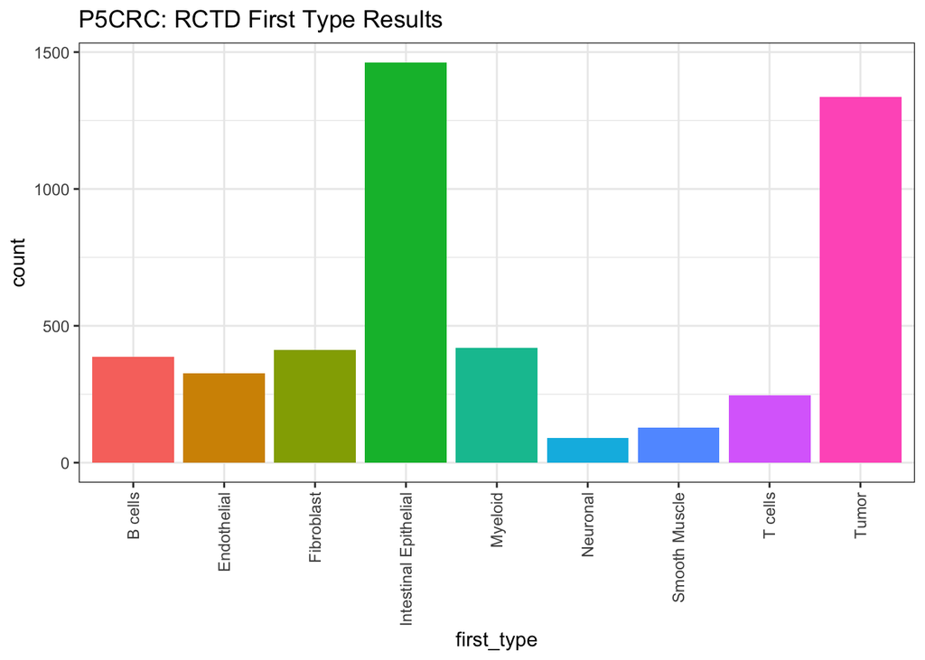

Figure 4: Number of sketched bins assigned to a cell type with RCTD.

```r
# Number of cell types annotated to each bin in sketch assay
ggplot(df_rctd_results,
       aes(x = first_type,
           fill = first_type)) +
  geom_bar() +
  theme_bw() + NoLegend() +
  ggtitle("P5CRC: RCTD First Type Results") +
  theme(axis.text.x = element_text(angle = 90,
                                   vjust = 0.5,
                                   hjust=1))
```

Just by looking at the total number of bins, this is a good reminder that we only have the RCTD results for the 5,000 bins we sketched to.

### Project RCTD results on all bins

Let us take a look at how many rows (bins) we have these annotations for:

```r
nrow(df_rctd_results)
```

```
[1] 4809
```

But didn’t our `sketch` assay include 5,000 bins? RCTD runs its own QC step that filters out bins with low expression or *rejects* bins where it is unable to map a cell type from the reference dataset. This is why we have fewer bins than we expected. So we are going to do some data wrangling to ensure that we keep track of all information. Including those ~200 bins without `first_type` labels. In a future step, we will set the label for these bins to be `unassigned`.

To do so, we are first going to do some wrangling to the results dataframe:

1. Append `_sketch` to all column names
2. Remove factors (to avoid downstream errors)

```r
# Update column names to have _sketch
# Add "sketch" to column names
colnames(df_rctd_results) <- paste0(colnames(df_rctd_results),
                                    "_sketch")

# Create column "cell" to merge on
# Removing factors for easier merging later
df_rctd_results <- df_rctd_results %>%
  mutate(cell = rownames(df_rctd_results)) %>%
  mutate(first_type_sketch = as.character(first_type_sketch),
         second_type_sketch = as.character(second_type_sketch),
         spot_class_sketch = as.character(spot_class_sketch))

# Make sure columns were generated
colnames(df_rctd_results)
```

```
 [1] "spot_class_sketch"    "first_type_sketch"    "second_type_sketch"
 [4] "first_class_sketch"   "second_class_sketch"  "min_score_sketch"
 [7] "singlet_score_sketch" "conv_all_sketch"      "conv_doublet_sketch"
[10] "cell"
```

Now, let us merge this information into our Seurat object. This step is necessary because in order to `ProjectData()`, we need the RCTD results to live in our `@meta.data` slot.

```r
# Create cell barcode in metadata
crc$cell <- rownames(crc@meta.data)
meta <- crc@meta.data

# Merge together RCTD results and metadata
meta <- left_join(x = meta,
                  y = df_rctd_results,
                  by = "cell")
rownames(meta) <- meta$cell

# Put meta into crc Seurat object
crc@meta.data <- meta
```

## Project back to full dataset

Now, we can run the `ProjectData()`, just like we did last time in order to project out RCTD results to the full CRC dataset.

```r
# Project back first_type to new column called first_type
# This will fail
crc <- ProjectData(
  object = crc,
  assay = "Spatial.008um",
  sketched.assay = "sketch_crc",
  full.reduction = "pca_crc",
  sketched.reduction = "pca.sketch_crc",
  dims = 1:30,
  refdata = list(spot_class = "spot_class_sketch",
                 first_type = "first_type_sketch",
                 second_type = "second_type_sketch"))
```

```
Error in `TransferLablesNN()`:
! wrong weights matrix input
```

Why did we get an error when we tried to get RCTD labels for the entire dataset? This is because we have those `NA` values for bins in the sketch assay. The `ProjectData()` function expects actual values for every sketched bin. Therefore, to get around this issue, we are going to label those bins as `unassigned` in the metadata.

```r
# Set value of unassigned to sketch bins that do not have values
# This is because ProjectData will throw errors otherwise
cols <- c("spot_class_sketch",
          "first_type_sketch",
          "second_type_sketch")

# Iterate through each column to set "unassigned" to NA values
for (col in cols) {
  # Find rows that are in sketch_cells and are NA
  na_rows <- cells_sketch[is.na(crc@meta.data[cells_sketch, col])]
  # Assign the value to unassigned
  crc@meta.data[na_rows, col] <- "unassigned"
}
```

**Number of unassigned bins**

We can use the `table()` function to quickly see how many unassigned bins we have in our dataset:

```r
# Show the number of bins assigned to each cell type, including unassigned
table(crc@meta.data$first_type_sketch)
```

```
              B cells           Endothelial            Fibroblast
                  387                   326                   413
Intestinal Epithelial               Myeloid              Neuronal
                 1462                   420                    91
        Smooth Muscle               T cells                 Tumor
                  127                   247                  1336
           unassigned
                  191
```

At this point, we have assigned labels for each bin in the sketch assay. So we can once again run `ProjectData()` and this time get cell type labels for each bin in our dataset.

```r
# Project back first_type to new column called first_type
crc <- ProjectData(
  object = crc,
  assay = "Spatial.008um",
  sketched.assay = "sketch_crc",
  full.reduction = "pca_crc",
  sketched.reduction = "pca.sketch_crc",
  dims = 1:30,
  refdata = list(spot_class = "spot_class_sketch",
                 first_type = "first_type_sketch",
                 second_type = "second_type_sketch"))
```

## Visualize RCTD results

Now that we have `first_type` values associated with each bin, we can visualize our dataset in a variety of different ways.

### Barplot

We can get an overview of how many bins we have with a barplot. As we might expect, the number of unassigned bins increased as we extrapolate the labels out to the larger dataset.

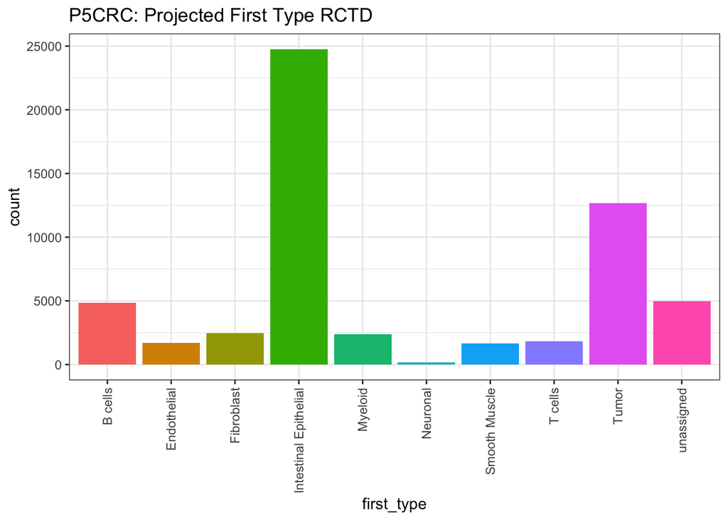

Figure 5: Number of bins assigned to a cell type with RCTD after `ProjectData()`.

```r
# Barplot of first_type labels after ProjectData()
ggplot(crc@meta.data,
       aes(x = first_type, fill = first_type)) +
  geom_bar() +
  theme_bw() + NoLegend() +
  ggtitle("P5CRC: Projected First Type RCTD") +
  theme(axis.text.x = element_text(angle = 90, vjust = 0.5, hjust=1))
```

### Spatial overlay

We can also see how the bins are located on the slide itself.

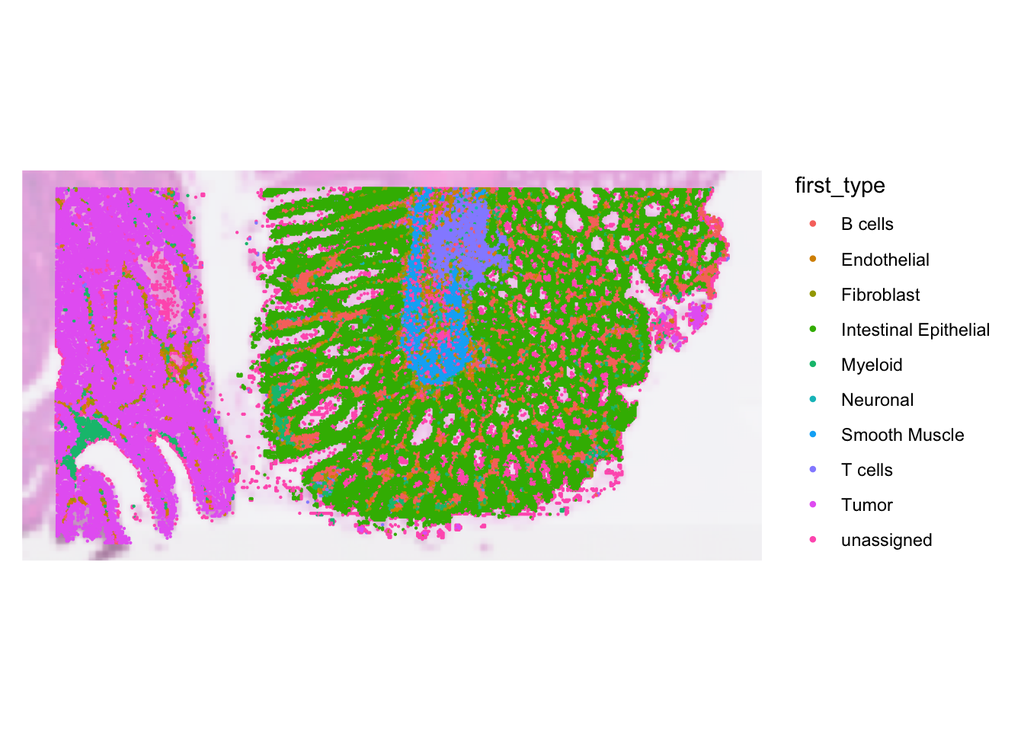

Figure 6: Spatial overlay of the first type RCTD results after `ProjectData()`.

```r
# Spatial plot of first_type labels after ProjectData()
SpatialDimPlot(crc,
               group.by = "first_type",
               pt.size.factor = 15,
               image.alpha = 0.5)
```

**Alternative spatial visualization**

Sometimes it can be difficult to see patterns for a given cell type when all of the cell types are present in the same plot. Due to this difficulty, we can also facet our different cell types into their own plots:

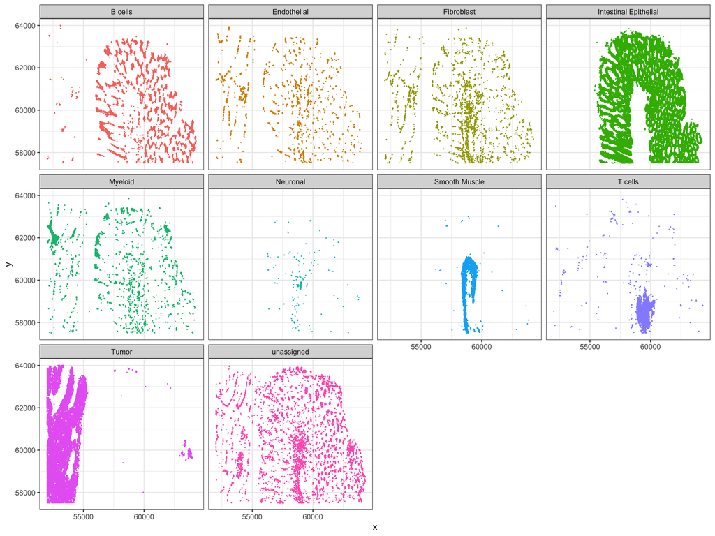

Figure 7: Spatial overlay of the first type RCTD results after `ProjectData()` split by first_type.

```r
# Grab x, y coordinates and first_type cell type labels
df <- FetchData(crc,
                vars = c("x", "y",
                         "first_type"))

# Create scatterplot
ggplot(df,
       aes(x = x, y = y,
           color = first_type)) +
  geom_point(size = 0.05) +
  theme_bw() +
  # Split by cell type label
  facet_wrap(~first_type) +
  NoLegend()
```

As we previously noted, the left-most region on th `P5CRC` slide is comprised primarily of tumor cells. There are some myeloid and fibroblast cells mixed throughout this region as well. The rest of the tissue contains mostly epithelial cells, which is to be expected when we consider the layered structure of the colon.

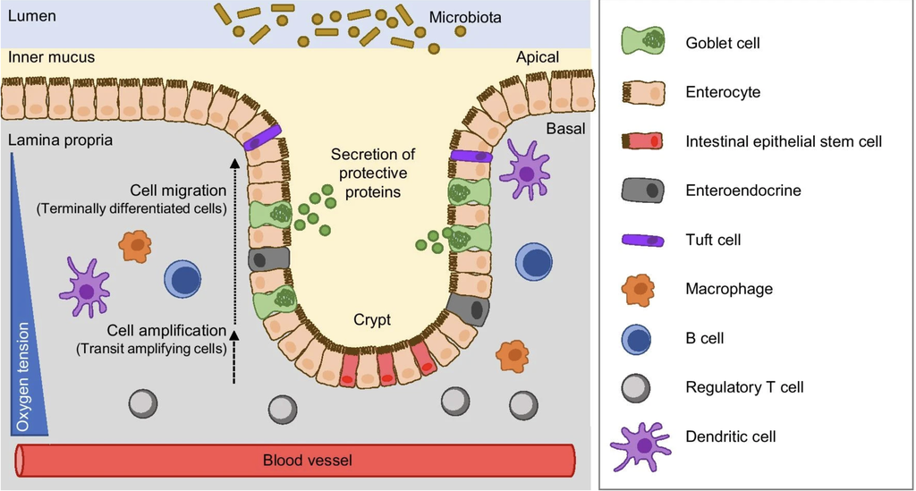

Figure 8: Schematic showing the cell type structure of the colon, where the epithelial layer lines the surface to form a barrier between the gut microbiome and the underlying immune compartment.  
*Image source: [Ternet et al. (2021)](https://link.springer.com/article/10.1186/s12964-021-00712-3)*

The colon wall is organized into distinct layers. The innermost surface facing the gut cavity is lined by epithelial cells (goblet, enterocyte, tuft cells), which form a structure known as Crypts of Lieberkühn. These cells form a barrier, selectively allowing interactions between the gut microbiome and the inner regions of the tissue (mucosa). Here, the immune component (T and B cells) are present. Right underneath there is another layer of muscle cells, known as the muscularis mucosae, which is responsible for the folded structure of the colon. Together, these layers allow the colon to control what passes from the gut cavity into the rest of the tissue.

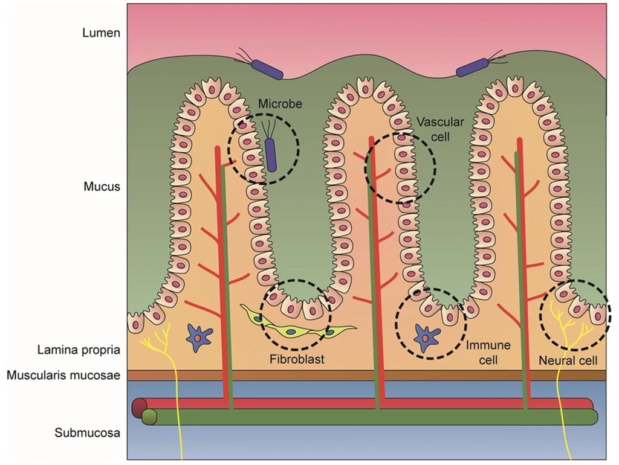

Figure 9: Schematic showing the cell type structure of the colon, where inner layers are comprised on immune, neuronal, and muscle cells.  
*Image source: [Min et al. (2020)](https://www.nature.com/articles/s12276-020-0386-0)*

This is consistent with what we observe in our own dataset, where the immune cells (B and T cells) are found deeper within the tissue rather than at the surface. Recall that this is the `P5CRC` sample, meaning that the structure will not be exactly as shown in these schematics due to the abnormalities caused by cancer. In the P5NAT sample, we will be able to more clearly see the normal colon structure outlined here.

### UMAP

We can now see how the cell types fall on our UMAP space.

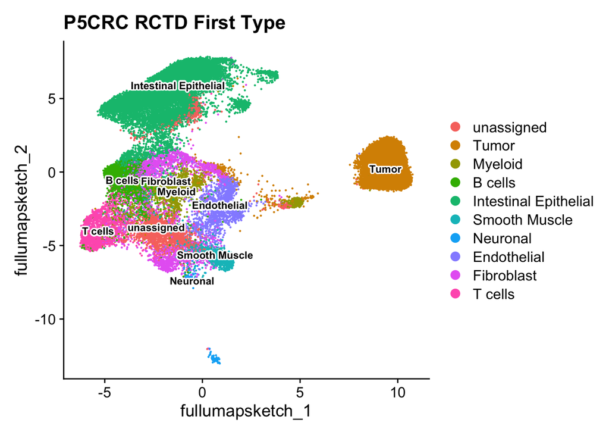

Figure 10: UMAP of the first type RCTD results after `ProjectData()`.

```r
# UMAP of reference dataset
Idents(crc) <- "first_type"
p <- DimPlot(crc,
             reduction = "full.umap.sketch") +
  ggtitle("P5CRC RCTD First Type")
LabelClusters(p, id = "ident",  fontface = "bold", size = 3,
              bg.colour = "white", bg.r = .2, force = 0)
```

As we might expect, the immune populations (myeloid, T and B cells) appear close to one another in UMAP space due to the similarity of their gene expression. The most distinctly clustered populations are the tumor and epithelial bins, which have very different gene expression patterns compared to the rest of the cell types in the dataset.

## P5CRC and P5NAT results

We have run RCTD of the full dataset for both P5CRC and P5NAT for you all to load and run the rest of the workshop with:

```r
# Load Seurat object with P5CRC and P5NAT cell type annotations
seurat_rctd <- readRDS("data/intermediate_seurat/seurat_RCTD.rds")
```

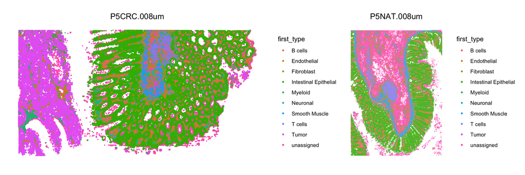

Figure 11: Spatial overlay of the first type RCTD results after `ProjectData()` for both samples.

```r
# Spatial plot of first_type labels after ProjectData()
SpatialDimPlot(seurat_rctd,
               group.by = "first_type",
               pt.size.factor = 15,
               image.alpha = 0)
```

**Exercise 1**

1. What is the sample-specific proportion for each `first_type`? Create a ggplot barplot showing the proportions of each cell type. *Hint: Refer back to the code we used here*.
2. Create a dotplot using the known marker genes for each cell type to see if the `first_type` labels align with known cell type genes.

```r
marker_list <- list(
  "B cells" = c("IGKC", "IGHM", "CD79A", "MS4A1", "MZB1"),
  "Endothelial cells" = c("PECAM1", "VWF", "PLVAP", "ENG", "KLF2"),
  "Fibroblasts" = c("COL1A1", "COL3A1", "DCN", "LUM", "COL6A2"),
  "Intestinal epithelial cells" = c("CLCA1", "FCGBP", "MUC2", "PIGR", "ZG16"),
  "Myeloid cells" = c("C1QC", "SELENOP", "SPP1", "LYZ", "CD68"),
  "Neural cells" = c("NRXN1", "L1CAM", "NCAM1", "VIP", "CALB2"),
  "Smooth muscle cells" = c("TAGLN", "ACTA2", "MYH11", "MYL9", "CNN1"),
  "T cells" = c("TRAC", "CD3E", "TRBC2", "IL7R", "CD52"),
  "Tumor cells" = c("CEACAM6", "CEACAM5", "EPCAM", "KRT8", "LCN2")
)
```

Do we generally agree with the annotation that was done with RCTD based upon these results?

Next Lesson >>

Back to Schedule